# Oscar Projekt

# Možemo li naslutiti kako je film ocijenjen pomoću drugih značajki?

Možemo iskoristiti nekoliko metoda kako bi vidjeli možemo li koristiti druge merike da bi mogli naslutiti ocjenu filma.

Prvo krećemo sa numeričkom analizom.

```r
# Biramo samo numeričke stupce za nalizu
numerical_data <- oscars_dataset2[, c("lenght", "imdb_rating", "imdb_votes",
                                       "tomato_rating", "tomato_count", "audience_rating", "audience_count")]

# Kalkuliramo matrix korelacije koji nam je pogod
cor_matrix <- cor(numerical_data, use = "complete.obs")
print(cor_matrix)
```

```
##                      lenght imdb_rating imdb_votes tomato_rating tomato_count
## lenght           1.00000000   0.2334096 0.26604443   -0.18968511   0.07762022
## imdb_rating      0.23340962   1.0000000 0.61672439    0.46632079   0.24633971
## imdb_votes       0.26604443   0.6167244 1.00000000    0.09744051   0.47035921
## tomato_rating   -0.18968511   0.4663208 0.09744051    1.00000000   0.12644534
## tomato_count     0.07762022   0.2463397 0.47035921    0.12644534   1.00000000
## audience_rating  0.13647250   0.8485251 0.33591478    0.50462680   0.15622655
## audience_count   0.18911348   0.1679893 0.31230476   -0.00915894   0.04615373
##                 audience_rating audience_count
## lenght               0.13647250     0.18911348
## imdb_rating          0.84852507     0.16798930
## imdb_votes           0.33591478     0.31230476
## tomato_rating        0.50462680    -0.00915894
## tomato_count         0.15622655     0.04615373
## audience_rating      1.00000000    -0.01560293
## audience_count      -0.01560293     1.00000000
```

Moramo analizirati kvalitativne stupce.

```r
genre_analysis <- oscars_dataset2 %>%
  group_by(main_genre) %>%
  summarise(
    avg_rating = mean(imdb_rating, na.rm = TRUE),
    movie_count = n()
  ) %>%
  arrange(desc(avg_rating))


print(genre_analysis)
```

```
## # A tibble: 14 × 3
##    main_genre avg_rating movie_count
##    <chr>           <dbl>       <int>
##  1 Animation        8.13           3
##  2 Crime            7.88          48
##  3 Family           7.8            1
##  4 Horror           7.77           3
##  5 Action           7.65          39
##  6 Biography        7.58         101
##  7 Drama            7.56         215
##  8 Adventure        7.56          45
##  9 Comedy           7.47         108
## 10 Film-Noir        7.45           2
## 11 Romance          6.7            1
## 12 Western          6.35           2
## 13 Musical          6.25           2
## 14 Music            5.7            1
```

Možemo se i zapitati imaju li Oscar pobjednici bolje ocjene.

```r
imdb_stats <- oscars_dataset %>%
  group_by(Award) %>%
  summarise(
    Prosjek_IMDb = mean(`IMDB Rating`, na.rm = TRUE),
    Medijan_IMDb = median(`IMDB Rating`, na.rm = TRUE),
    Broj_filmova = n()
  )

print(imdb_stats)
```

```
## # A tibble: 2 × 4
##   Award   Prosjek_IMDb Medijan_IMDb Broj_filmova
##   <chr>          <dbl>        <dbl>        <int>
## 1 Nominee         7.53          7.6          477
## 2 Winner          7.78          7.9           94
```

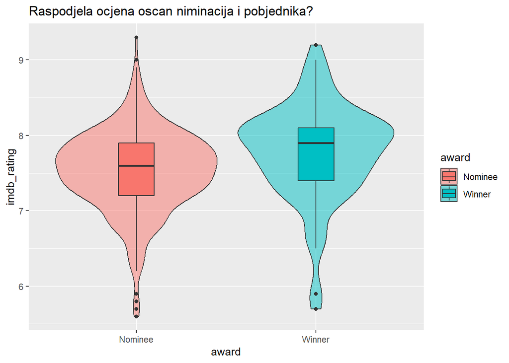

```r
#Vidimo da ima vidljive razlike u prosjeku i u medijanu
ggplot(oscars_dataset2, aes(x = award, y = imdb_rating, fill = award)) +
  geom_violin(alpha = 0.5) +
  geom_boxplot(width = 0.2) +
  labs(title = "Raspodjela ocjena oscan niminacija i pobjednika?")
```

```r
# Pomoću t testa možemo testirati jesu li prosjeci ova dva skupa stvarno statistički različita
# Znamo da su dva skupa nezavisna ner ne dijele istu značajku
#Koristi ćemo t test pa prvo se moramo uvjeriti  normalnost podataka"
winners <- oscars_dataset2 %>% filter(award == "Winner") %>% select(imdb_rating) %>% pull(imdb_rating)
shapiro.test(winners)
```

```
##
##  Shapiro-Wilk normality test
##
## data:  winners
## W = 0.95032, p-value = 0.001322
```

```r
nominees <- oscars_dataset2 %>% filter(award == "Nominee") %>% select(imdb_rating) %>% pull(imdb_rating)
shapiro.test(nominees)
```

```
##
##  Shapiro-Wilk normality test
##
## data:  nominees
## W = 0.97874, p-value = 1.939e-06
```

```r
# pošto je p < 0.01 za oba testa možemo zaključiti da nisu normalno distribuirani
#Moramo  koristi ne parametarsku metodu
wilcox.test(winners, nominees, alternative = "greater")
```

```
##
##  Wilcoxon rank sum test with continuity correction
##
## data:  winners and nominees
## W = 28913, p-value = 4.294e-06
## alternative hypothesis: true location shift is greater than 0
```

```r
# p < 0.0001 možemo gotovo sigurno odbaciti hipotezu u korist toga da oscar pobjednici imaju bolji rating
```

Biti pobjednik oscara jedan je od prediktora višeg ratinga

Možemo pretposatvi da neki producenti proizvode bolje filmove

```r
#Kako bi mogli vidjeti koji studiji proizvode visoko ocjenjene filmove moramo znati interval pouzdanosti za naš porsječan imdb rating
#Koristimo boostrap metodu jer imdb rating nisu normalno distribuirani i robusno je

# Funkcija koja računa prosjek (potrebna za bootstrap)
boot_mean <- function(data, indices) {
  return(mean(data[indices], na.rm = TRUE))
}

# Pokretanje bootstrapa (1000 simulacija)
set.seed(553343) # Za ponovljivost
boot_results <- boot(data = oscars_dataset2$imdb_rating, statistic = boot_mean, R = 1000)

# Dobivanje 95% intervala pouzdanosti
ci <- boot.ci(boot_results,conf = 0.99, type = "perc")
#perc type Directly uses quantiles from the bootstrap distribution as interval endpoints (e.g., the 2.5th and 97.5th percentiles for a 95% CI).
#types valjda treba ili perc ili basic

gornja_granica <- ci$percent[5]

#Sve prodkcijske kompanije koje su iznad gornje granice možemo poprilično sigurno reći da proizvode visoko ocijenjene filmove pa su dobar šrediktor uspijeha
uspjesni_producenti <- oscars_dataset2 %>%
  group_by(producer) %>%
  summarise(
    prosjek_producenta = mean(imdb_rating, na.rm = TRUE),
    broj_filmova = n()
  ) %>%
  filter(broj_filmova >= 3) %>%
  filter(prosjek_producenta > gornja_granica) %>%
  arrange(desc(prosjek_producenta))

print(uspjesni_producenti)
```

```
## # A tibble: 7 × 3
##   producer                          prosjek_producenta broj_filmova
##   <chr>                                          <dbl>        <int>
## 1 Lawrence Bender                                 8.5             3
## 2 Stanley Kubrick                                 8.27            3
## 3 Irwin Winkler and Robert Chartoff               8.03            3
## 4 Sam Spiegel                                     7.92            4
## 5 Stanley Kramer                                  7.73            6
## 6 Robert Wise                                     7.7             3
## 7 Selznick International Pictures                 7.7             5
```

Zaključujemo da su ovih 7 producenata proizvode statistički bolje filmove po tome što imaju više filmova (znaći da imamo barem neku populaciju za proučiti) i prosjećna ocjena njihovih filmova je veća od gornje granice intervala pouzdanosti za alpha = 0.01

#Možemo li pomoću dostupnih značajki pouzdano razlikovati pobjednike od ostalih?

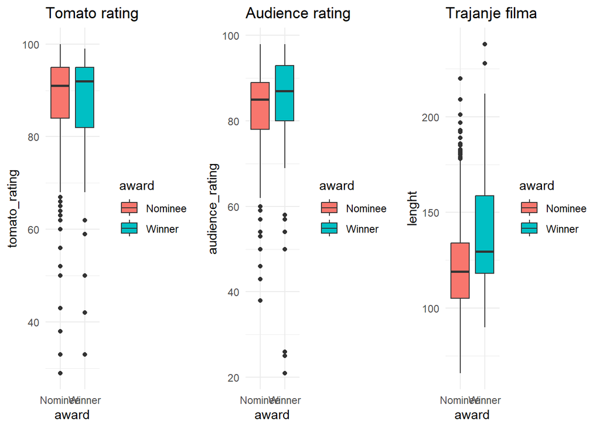

```r
# 1. Vizualizacija - Boxplotovi za ključne metrike
p1 <- ggplot(oscars_dataset2, aes(x = award, y = tomato_rating, fill = award)) +
  geom_boxplot() +
  labs(title = "Tomato rating ") + theme_minimal()

p2 <- ggplot(oscars_dataset2, aes(x = award, y = lenght, fill = award)) +
  geom_boxplot() +
  labs(title = "Trajanje filma") + theme_minimal()

p3 <- ggplot(oscars_dataset2, aes(x = award, y = audience_rating, fill = award)) +
  geom_boxplot() +
  labs(title = "Audience rating") + theme_minimal()

grid.arrange(p1, p3, p2, ncol = 3)
```

```r
# 2. Statistički testovi (Wilcoxon rank-sum test)
# H0: Nema razlike u distribuciji između pobjednika i nominiranih
test_imdb <- wilcox.test(imdb_rating ~ award, data = oscars_dataset2)
test_len <- wilcox.test(lenght ~ award, data = oscars_dataset2)
test_tomato <- wilcox.test(tomato_rating ~ award, data = oscars_dataset2)

print(paste("P-vrijednost za IMDb:", test_imdb$p.value))
```

```
## [1] "P-vrijednost za IMDb: 8.58788614504331e-06"
```

```r
print(paste("P-vrijednost za Duljinu:", test_len$p.value))
```

```
## [1] "P-vrijednost za Duljinu: 6.71961208650246e-06"
```

```r
print(paste("P-vrijednost za Tomato:", test_tomato$p.value))
```

```
## [1] "P-vrijednost za Tomato: 0.91513884267567"
```